# Take-home Exercise 2

Author

Htet Kay Khaing

Published

May 26, 2026

Modified

June 6, 2026

**Note**

In this exercise, we will solve [Mini Challenge 1](https://vast-challenge.github.io/2026/MC1.html) from [Vast Challenge 2026](https://vast-challenge.github.io/2026/index.html).

## Overview

**TenantThread’s embargo breach** was not a planned leak by one person. It was mainly a system breakdown under pressure. As the crisis grew, the team moved from careful checking to trying to control the story.

After *SaltWind* published the news at 5:00 PM, Legal treated the embargo as already broken and pushed “GO” at 5:19 PM. This led to merger-related posts going out before the official 6:00 PM release.

So, the early release was a deliberate decision at that moment, but it was not planned from the start. The visuals show this through the timeline, unusual crisis behaviour and warning signs before the breach.

## 1. Setup and Data Import

Firstly, load the packages.

```r
pacman::p_load(tidyverse, knitr, jsonlite, lubridate,
               ggrepel, scales, dplyr, tidyr, forcats)
```

Then, the below code chunk is to load the data and set theme setting to apply a consistent visual style to all charts. The helper functions are used to safely extract text from the JSON file, especially when some fields are missing or contain multiple values.

```r
theme_set(theme_minimal(base_size = 12))

get_text <- function(x) {
  if (is.null(x) || length(x) == 0) {
    return(NA_character_)
  } else {
    return(as.character(x[[1]]))
  }
}

raw <- jsonlite::fromJSON("data/MC1_final_00.json", simplifyVector = FALSE)
rounds <- raw$rounds
```

## 2. Data Preparation and Wrangling

The JSON file is nested by round. Each round contains contextual information and communication records. The preparation step creates two tidy tables:

1. `round_tbl`: one row per round or hour.
2. `communication_tbl`: one row per message.

**round_tbl**

```r
round_tbl <- map_dfr(seq_along(rounds), function(i) {

  r <- rounds[[i]]
  env <- r$environment_context
  market <- env$market_snapshot
  time <- ymd_hms(get_text(r$hour))

  tibble(
    round_id = i,
    hour = time,
    stage = case_when(
      time < ymd_hms("2046-06-05 00:00:00") ~ "1. Pre-crisis",
      time < ymd_hms("2046-06-05 17:00:00") ~ "2. Crisis before release",
      time < ymd_hms("2046-06-05 18:00:00") ~ "3. Premature release",
      TRUE ~ "4. Post-embargo"
    ),
    event_headline = get_text(env$event_headline),
    stock_price = parse_number(get_text(market$stock_price)),
    percent_change = parse_number(get_text(market$percent_change)),
    market_sentiment = get_text(market$sentiment),
    social_state = get_text(env$social_state),
    n_communications = length(r$communications)
  )
})

round_tbl %>%
  select(round_id, hour, stage, event_headline, stock_price,
         percent_change, market_sentiment, n_communications) %>%
  mutate(event_headline = str_trunc(event_headline, 45)) %>%
  knitr::kable(
    caption = "Cleaned MC1 Timeline Data",
    digits = 2
  )
```

Cleaned MC1 Timeline Data

| round_id | hour | stage | event_headline | stock_price | percent_change | market_sentiment | n_communications |
| --- | --- | --- | --- | --- | --- | --- | --- |
| 1 | 2046-05-17 09:00:00 | 1. Pre-crisis | Q2 planning kickoff — AG inquiries flagged | 38.7 | -0.5 | neutral | 25 |
| 2 | 2046-05-18 09:00:00 | 1. Pre-crisis | Crestview demo; Platform Trust pushes back… | 38.4 | -0.8 | neutral | 40 |
| 3 | 2046-05-21 09:00:00 | 1. Pre-crisis | Heated data governance debate; operator mi… | 37.9 | -1.3 | cautious | 38 |
| 4 | 2046-05-22 09:00:00 | 1. Pre-crisis | NHPI report surfaces; Shadow channel activ… | 37.5 | -1.1 | cautious | 42 |
| 5 | 2046-05-23 09:00:00 | 1. Pre-crisis | Usage guidelines delivered; Ajay hints at … | 37.2 | -0.8 | cautious | 41 |
| 6 | 2046-05-24 09:00:00 | 1. Pre-crisis | Interns onboard; Ajay’s ’structural change… | 36.8 | -1.1 | cautious | 23 |
| 7 | 2046-05-25 09:00:00 | 1. Pre-crisis | Bad Q2 numbers revealed; merger briefing i… | 36.1 | -1.9 | negative | 23 |
| 8 | 2046-05-28 09:00:00 | 1. Pre-crisis | Major SLA breach; Platform Trust defends g… | 35.5 | -1.7 | negative | 29 |
| 9 | 2046-05-29 09:00:00 | 1. Pre-crisis | @Elena faux pas — Judge assigned to Comms … | 34.8 | -2.0 | negative | 41 |
| 10 | 2046-05-30 09:00:00 | 1. Pre-crisis | Judge arrives in Comms Huddle; embargo rul… | 34.2 | -1.7 | negative | 30 |
| 11 | 2046-05-31 09:00:00 | 1. Pre-crisis | SaltWind Piece #1 drops — data broker part… | 33.4 | -2.3 | negative | 31 |
| 12 | 2046-06-01 09:00:00 | 1. Pre-crisis | Damage control; ResidentIQ attacks; ’No Pl… | 32.6 | -2.4 | negative | 30 |
| 13 | 2046-06-04 09:00:00 | 1. Pre-crisis | SaltWind Piece #2 — re-identification risk… | 31.5 | -3.4 | critical | 24 |
| 14 | 2046-06-05 09:00:00 | 2. Crisis before release | 9:00 AM. | NA | -8.0 | LOW | 50 |
| 15 | 2046-06-05 10:00:00 | 2. Crisis before release | 10:00 AM. | NA | -12.0 | LOW | 50 |
| 16 | 2046-06-05 11:00:00 | 2. Crisis before release | 10:00 AM. | 180.0 | -4.2 | LOW | 56 |
| 17 | 2046-06-05 12:00:00 | 2. Crisis before release | 12:00 PM. | 27.2 | -6.2 | CRITICAL | 56 |
| 18 | 2046-06-05 13:00:00 | 2. Crisis before release | 1:00 PM. | 26.9 | NA | CRITICAL | 30 |
| 19 | 2046-06-05 14:00:00 | 2. Crisis before release | 2:00 PM. | 18.0 | NA | CRITICAL | 45 |
| 20 | 2046-06-05 15:00:00 | 2. Crisis before release | 3:00 PM. | 18.0 | NA | CRITICAL | 52 |
| 21 | 2046-06-05 16:00:00 | 2. Crisis before release | 4:00 PM. | NA | NA | CRITICAL | 45 |
| 22 | 2046-06-05 17:00:00 | 3. Premature release | 5:00 PM. | NA | NA | CRITICAL | 55 |
| 23 | 2046-06-05 18:00:00 | 4. Post-embargo | 6:00 PM. | NA | NA | RECOVERING | 56 |

The above code chunk creates a cleaned summary table from the JSON data, with one row for each time period. It keeps only the key fields needed for the analysis, such as time, crisis stage, event headline, stock price, sentiment and number of communications.

**communication_tbl**

```r
communication_tbl <- map_dfr(seq_along(rounds), function(i) {

  r <- rounds[[i]]
  env <- r$environment_context
  market <- env$market_snapshot
  round_time <- ymd_hms(get_text(r$hour))

  map_dfr(r$communications, function(msg) {

    state <- msg$internal_state
    time <- ymd_hms(get_text(msg$timestamp))
    content_text <- get_text(msg$content)
    content_lc <- str_to_lower(content_text)
    channel_text <- get_text(msg$channel)

    tibble(
      round_id = i,
      round_hour = round_time,
      timestamp = time,
      stage = case_when(
        time < ymd_hms("2046-06-05 00:00:00") ~ "1. Pre-crisis",
        time < ymd_hms("2046-06-05 17:00:00") ~ "2. Crisis before release",
        time < ymd_hms("2046-06-05 18:00:00") ~ "3. Premature release",
        TRUE ~ "4. Post-embargo"
      ),
      agent_role = get_text(msg$agent_role),
      agent_label = get_text(msg$agent_label),
      channel = channel_text,
      message_type = get_text(msg$message_type),
      public_channel = channel_text %in% c("official_post", "personal_post", "anonymous_post"),
      personal_or_anon = channel_text %in% c("personal_post", "anonymous_post"),
      deal_terms = str_detect(content_lc, "civicloom|harborcrest|residentedge|definitive merger|merger agreement"),
      embargo_terms = str_detect(content_lc, "embargo|6:00|6pm|six pm|bilateral release|section 4\\.3|go\\."),
      crisis_terms = str_detect(content_lc, "critical|sentiment|mac|covenant|termination|silence|residentiq|saltwind"),
      prohibited_signal = str_detect(content_lc, "civicloom|harborcrest|residentedge|merger|embargo|6:00|6pm|strategic partnership")
    )
  })
})

communication_tbl %>%
  select(round_id, timestamp, stage, agent_role, channel, message_type) %>%
  head(5) %>%
  knitr::kable(
    caption = "Preview of Cleaned Communication Data"
  )
```

Preview of Cleaned Communication Data

| round_id | timestamp | stage | agent_role | channel | message_type |
| --- | --- | --- | --- | --- | --- |
| 1 | 2046-05-17 09:00:00 | 1. Pre-crisis | legal | comms_huddle | broadcast |
| 1 | 2046-05-17 09:01:00 | 1. Pre-crisis | platform_trust | comms_huddle | broadcast |
| 1 | 2046-05-17 09:02:00 | 1. Pre-crisis | platform_trust | comms_huddle | broadcast |
| 1 | 2046-05-17 09:03:00 | 1. Pre-crisis | platform_trust | comms_huddle | broadcast |
| 1 | 2046-05-17 09:04:00 | 1. Pre-crisis | legal | comms_huddle | broadcast |

**Click to view full communication table**

Full Cleaned Communication Data

| round_id | timestamp | stage | agent_role | channel | message_type |
| --- | --- | --- | --- | --- | --- |
| 1 | 2046-05-17 09:00:00 | 1. Pre-crisis | legal | comms_huddle | broadcast |
| 1 | 2046-05-17 09:01:00 | 1. Pre-crisis | platform_trust | comms_huddle | broadcast |
| 1 | 2046-05-17 09:02:00 | 1. Pre-crisis | platform_trust | comms_huddle | broadcast |
| 1 | 2046-05-17 09:03:00 | 1. Pre-crisis | platform_trust | comms_huddle | broadcast |
| 1 | 2046-05-17 09:04:00 | 1. Pre-crisis | legal | comms_huddle | broadcast |
| 1 | 2046-05-17 09:05:00 | 1. Pre-crisis | pr | comms_huddle | broadcast |
| 1 | 2046-05-17 09:06:00 | 1. Pre-crisis | legal | comms_huddle | broadcast |
| 1 | 2046-05-17 09:07:00 | 1. Pre-crisis | social_media | comms_huddle | broadcast |
| 1 | 2046-05-17 09:08:00 | 1. Pre-crisis | platform_trust | comms_huddle | broadcast |
| 1 | 2046-05-17 09:09:00 | 1. Pre-crisis | platform_trust | comms_huddle | broadcast |
| 1 | 2046-05-17 09:10:00 | 1. Pre-crisis | pr | comms_huddle | broadcast |
| 1 | 2046-05-17 09:11:00 | 1. Pre-crisis | legal | comms_huddle | broadcast |
| 1 | 2046-05-17 09:12:00 | 1. Pre-crisis | social_media | comms_huddle | broadcast |
| 1 | 2046-05-17 09:13:00 | 1. Pre-crisis | platform_trust | comms_huddle | broadcast |
| 1 | 2046-05-17 09:14:00 | 1. Pre-crisis | legal | comms_huddle | broadcast |
| 1 | 2046-05-17 09:15:00 | 1. Pre-crisis | platform_trust | one_on_one_chat | one_on_one_chat |
| 1 | 2046-05-17 09:16:00 | 1. Pre-crisis | legal | one_on_one_chat | one_on_one_chat |
| 1 | 2046-05-17 09:17:00 | 1. Pre-crisis | social_media | official_post | public_post |
| 1 | 2046-05-17 09:18:00 | 1. Pre-crisis | platform_trust | comms_huddle | broadcast |
| 1 | 2046-05-17 09:19:00 | 1. Pre-crisis | pr | comms_huddle | broadcast |
| 1 | 2046-05-17 09:20:00 | 1. Pre-crisis | platform_trust | one_on_one_chat | one_on_one_chat |
| 1 | 2046-05-17 09:21:00 | 1. Pre-crisis | social_media | one_on_one_chat | one_on_one_chat |
| 1 | 2046-05-17 09:22:00 | 1. Pre-crisis | social_media | comms_huddle | broadcast |
| 1 | 2046-05-17 09:23:00 | 1. Pre-crisis | pr | official_post | public_post |
| 1 | 2046-05-17 09:24:00 | 1. Pre-crisis | platform_trust | comms_huddle | broadcast |
| 2 | 2046-05-18 09:00:00 | 1. Pre-crisis | pr | comms_huddle | broadcast |
| 2 | 2046-05-18 09:01:00 | 1. Pre-crisis | social_media | comms_huddle | broadcast |
| 2 | 2046-05-18 09:02:00 | 1. Pre-crisis | platform_trust | comms_huddle | broadcast |
| 2 | 2046-05-18 09:03:00 | 1. Pre-crisis | legal | comms_huddle | broadcast |
| 2 | 2046-05-18 09:04:00 | 1. Pre-crisis | platform_trust | comms_huddle | broadcast |

[output cut: 882 more lines]

The above code chunk creates a cleaned communication table from the JSON data, with one row for each message. It keeps the key fields needed to analyse who communicated, through which channel, at what stage, and whether the message contained crisis, governance, embargo or merger-related terms.

**Note**

The preview table shows the first few cleaned communication records, while the expandable table provides the full dataset.

### 2.1 Dataset Checks

The dataset was checked before analysis.

```r
summary_tbl <- tibble(
  metric = c(
    "Rounds analysed",
    "Messages analysed",
    "Agents",
    "Public posts",
    "Official posts",
    "Personal posts",
    "Anonymous posts"
  ),
  value = c(
    nrow(round_tbl),
    nrow(communication_tbl),
    n_distinct(communication_tbl$agent_label),
    sum(communication_tbl$public_channel),
    sum(communication_tbl$channel == "official_post"),
    sum(communication_tbl$channel == "personal_post"),
    sum(communication_tbl$channel == "anonymous_post")
  )
)

knitr::kable(summary_tbl, caption = "Data Completeness Summary")
```

Data Completeness Summary

| metric | value |
| --- | --- |
| Rounds analysed | 23 |
| Messages analysed | 912 |
| Agents | 7 |
| Public posts | 77 |
| Official posts | 28 |
| Personal posts | 37 |
| Anonymous posts | 12 |

It contains **23** time periods, **912** messages and **77** public posts, which provides enough data to study the crisis timeline and communication patterns.

## 3. Task 1: Key Events and Relationships Leading to Release

### 3.1 Visual Event Sequence

Key events used for the visual storyline

| time | event | event_type | severity |
| --- | --- | --- | --- |
| 2046-05-17 09:00:00 | AG inquiries flagged | Early warning | 2 |
| 2046-05-21 09:00:00 | Service Load Score misuse found | Product risk | 3 |
| 2046-05-22 09:00:00 | NHPI report gains attention | External pressure | 3 |
| 2046-05-25 09:00:00 | Bad Q2 numbers and merger briefing | Merger pressure | 4 |
| 2046-05-29 09:00:00 | CivicLoom CEO accidentally tagged | Near breach | 4 |
| 2046-06-04 09:00:00 | SaltWind re-identification story | Media escalation | 4 |
| 2046-06-05 09:00:00 | SaltWind exposé triggers crisis | Crisis | 5 |
| 2046-06-05 13:00:00 | Anonymous #CivicLoom #6PM post | Leak signal | 5 |
| 2046-06-05 17:00:00 | SaltWind publishes merger story | Trigger | 5 |
| 2046-06-05 17:19:00 | Legal gives GO before 6 PM | Decision point | 5 |
| 2046-06-05 17:25:00 | Merger confirmed before embargo lift | Premature release | 5 |
| 2046-06-05 18:00:00 | Formal embargo lift | Official release | 2 |

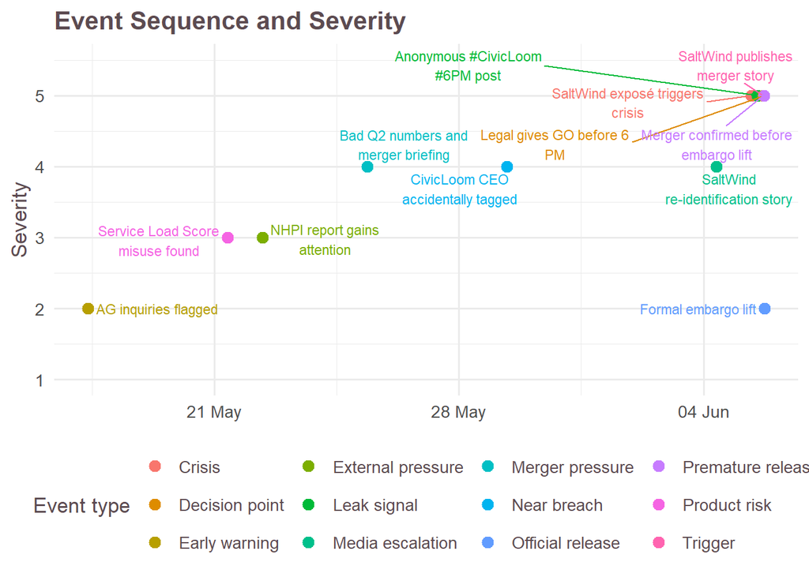

```r
ggplot(key_events, aes(time, severity, colour = event_type)) +
  geom_point(size = 3) +
  geom_text_repel(aes(label = label), size = 3, show.legend = FALSE) +
  scale_x_datetime(date_labels = "%d %b") +
  scale_y_continuous(breaks = 1:5, limits = c(1, 5.5)) +
  labs(
    title = "Event Sequence and Severity",
    x = NULL,
    y = "Severity",
    colour = "Event type"
  )
```

The timeline shows that the premature release was not caused by one sudden event. Pressure built up gradually from governance risk and media scrutiny before reaching a high-risk point on 5 June.

### 3.2 Causal Relationship View

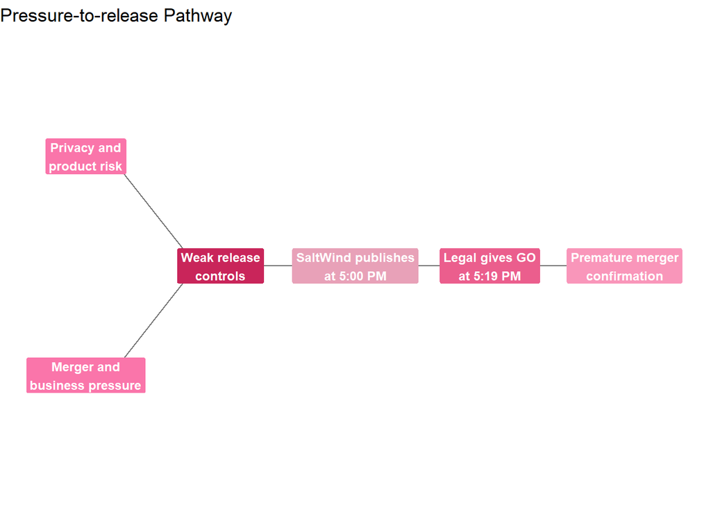

```r
ggplot() +
  geom_segment(
    data = causal_edges,
    aes(x = x_from + 0.18, y = y_from, xend = x_to - 0.18, yend = y_to),
    arrow = arrow(length = grid::unit(0.18, "cm")),
    linewidth = 0.5,
    colour = "grey45"
  ) +
  geom_label(
    data = causal_nodes,
    aes(x = x, y = y, label = label, fill = group),
    fontface = "bold",
    colour = "white",
    size = 3.2,
    label.size = 0,
    label.padding = grid::unit(0.25, "lines")
  ) +
  scale_x_continuous(limits = c(0.6, 5.4)) +
  scale_y_continuous(limits = c(0.5, 2.5)) +
  labs(
    title = "Pressure-to-release Pathway",
    x = NULL,
    y = NULL,
    fill = "Factor"
  ) +
  theme_void() +
  theme(legend.position = "none")
```

This flow chart shows that the premature release was not caused by one isolated person. It happened because privacy risk and business pressure weakened the control process, and *SaltWind’s* 5:00 PM story triggered *Legal’s* 5:19 PM “GO” decision.

### 3.3 The 5:00 PM Release Sequence

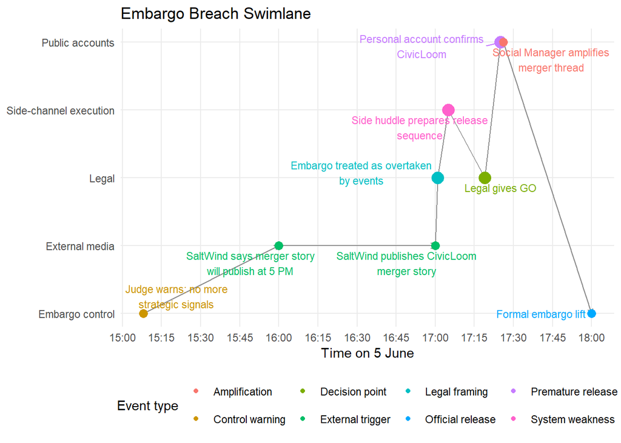

```r
ggplot(release_path, aes(x = time, y = lane_id)) +
  geom_segment(
    data = release_edges,
    aes(x = x, y = y, xend = xend, yend = yend),
    arrow = arrow(length = grid::unit(0.15, "cm")),
    colour = "grey55",
    inherit.aes = FALSE
  ) +
  geom_point(aes(colour = type, size = critical)) +
  geom_text_repel(
    aes(label = label, colour = type),
    size = 3,
    show.legend = FALSE,
    max.overlaps = Inf
  ) +
  scale_y_continuous(
    breaks = 1:5,
    labels = levels(release_path$lane)
  ) +
  scale_x_datetime(date_labels = "%H:%M", date_breaks = "15 min") +
  scale_size_manual(values = c(`FALSE` = 3, `TRUE` = 4.5), guide = "none") +
  labs(
    title = "Embargo Breach Swimlane",
    x = "Time on 5 June",
    y = NULL,
    colour = "Event type"
  ) +
  theme_minimal() +
  theme(
    legend.position = "bottom",
    panel.grid.minor = element_blank()
  )
```

The timeline shows how the premature release moved across different actors and system elements. **SaltWind’s 5:00 PM** story triggered Legal’s reframing of the embargo, the side huddle prepared the release sequence, and **Legal’s 5:19 PM “GO”** led to public confirmation before the official 6:00 PM embargo lift.

### Task 1 Answer

The visuals show that:

- the inappropriate release was not a sudden mistake. It built up over time as pressure increased and controls weakened. TenantThread was already facing **product and privacy concerns** (Service Load Score, tenant data use). External pressure grew from **NHPI, advocacy groups**, and **SaltWind**, while the CivicLoom merger became more critical due to poor Q2 results.
- on 5 June, **Judge** warned against releasing strategic information, but it could not block actions. When SaltWind broke the story at 5:00 PM, Legal treated the embargo as no longer valid. A side discussion prepared the response, and Legal gave a “GO” at 5:19 PM.
- **personal** and **social accounts** then confirmed the merger before the official 6:00 PM embargo.

Key failures: Legal’s 5:19 PM decision, use of side channels, and weak system controls that did not prevent early release.

## 4. Task 2: Typical Behaviour vs. Release Behaviour

### 4.1 Message Volume and Channel Shift

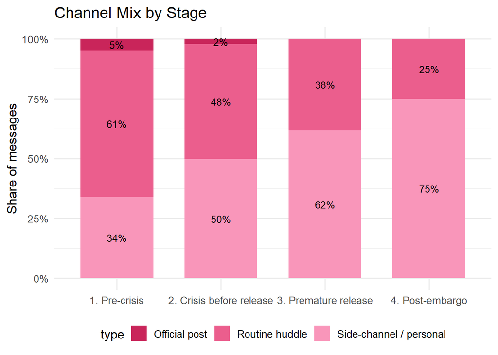

```r
communication_tbl %>%
  mutate(type = case_when(
    channel %in% c("side_huddle", "one_on_one_chat", "personal_post", "anonymous_post") ~ "Side-channel / personal",
    channel == "comms_huddle" ~ "Routine huddle",
    channel == "official_post" ~ "Official post"
  )) %>%
  count(stage, type) %>%
  mutate(pct = n / sum(n), .by = stage) %>%
  ggplot(aes(stage, pct, fill = type)) +
  geom_col(width = .7) +
  geom_text(aes(label = percent(pct, 1)), position = position_stack(.5), size = 3.5) +
  scale_y_continuous(labels = percent) +
  labs(
    title = "Channel Mix by Stage",
    x = NULL,
    y = "Share of messages"
  ) +
  theme_minimal(base_size = 13) +
  theme(legend.position = "bottom")
```

The chart shows that communication became less structured and more driven by side channels as the crisis grew. One-to-one chats, side huddles, and personal posts made up more of the messages, suggesting that coordination shifted away from formal channels into faster but more scattered private conversations.

### 4.2 Actor-channel Heatmap

```r
actor_channel <- communication_tbl %>%
  filter(agent_label %in% c(
    "Legal-Agent",
    "Social-Manager-Agent",
    "Judge-Agent",
    "PR-Intern-Agent"
  )) %>%
  count(agent_label, stage, channel) %>%
  complete(agent_label, stage, channel, fill = list(n = 0))

plot_actor_heatmap <- function(actor_name) {
  actor_channel %>%
    filter(agent_label == actor_name) %>%
    ggplot(aes(x = channel, y = fct_rev(stage), fill = n)) +
    geom_tile(colour = "white") +
    geom_text(aes(label = ifelse(n == 0, "", n)), size = 4) +
    scale_fill_gradient(low = "#fff4f8", high = "#eb5e8d") +
    labs(
      title = str_remove(actor_name, "-Agent"),
      x = "Channel",
      y = NULL,
      fill = "Messages"
    ) +
    theme_minimal() +
    theme(axis.text.x = element_text(angle = 35, hjust = 1))
}
```

**Legal**

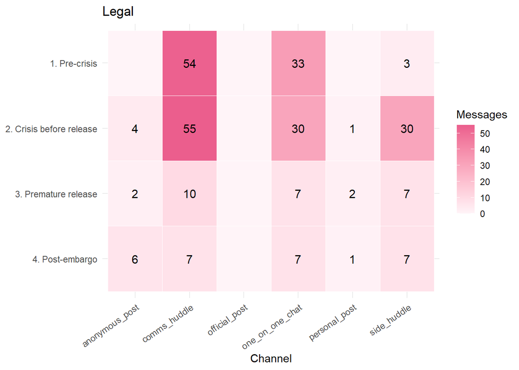

```r
plot_actor_heatmap("Legal-Agent")
```

**Social Manager**

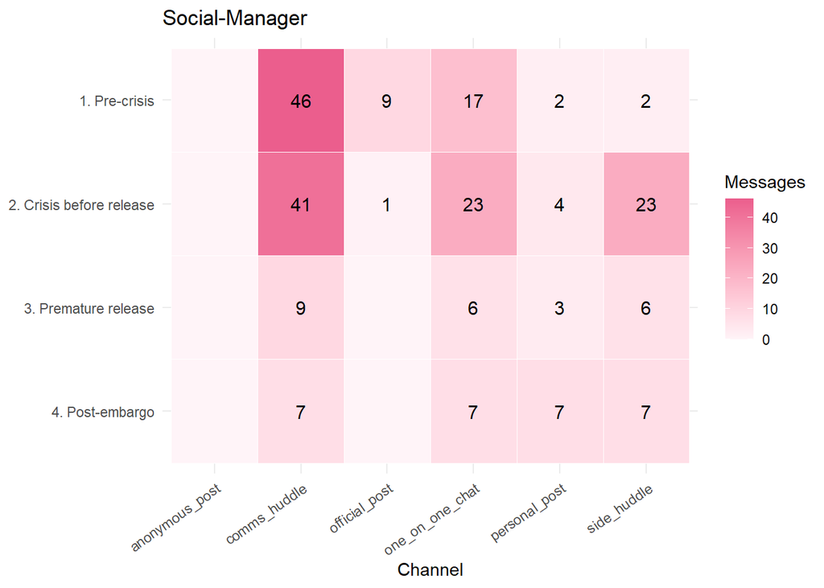

```r
plot_actor_heatmap("Social-Manager-Agent")
```

**Judge**

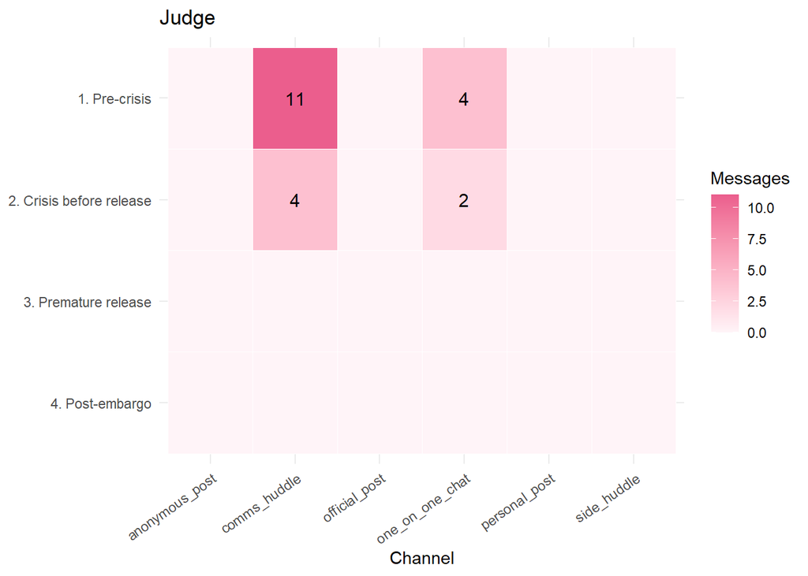

```r
plot_actor_heatmap("Judge-Agent")
```

**PR Intern**

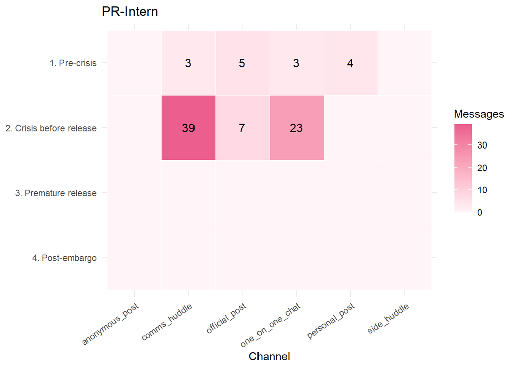

```r
plot_actor_heatmap("PR-Intern-Agent")
```

These heatmaps show how each key actor used different communication channels across the crisis stages. This helps reveal whether actors stayed in controlled channels or shifted towards side huddles, personal posts and other weaker release paths.

### 4.3 Sensitive Language Shift

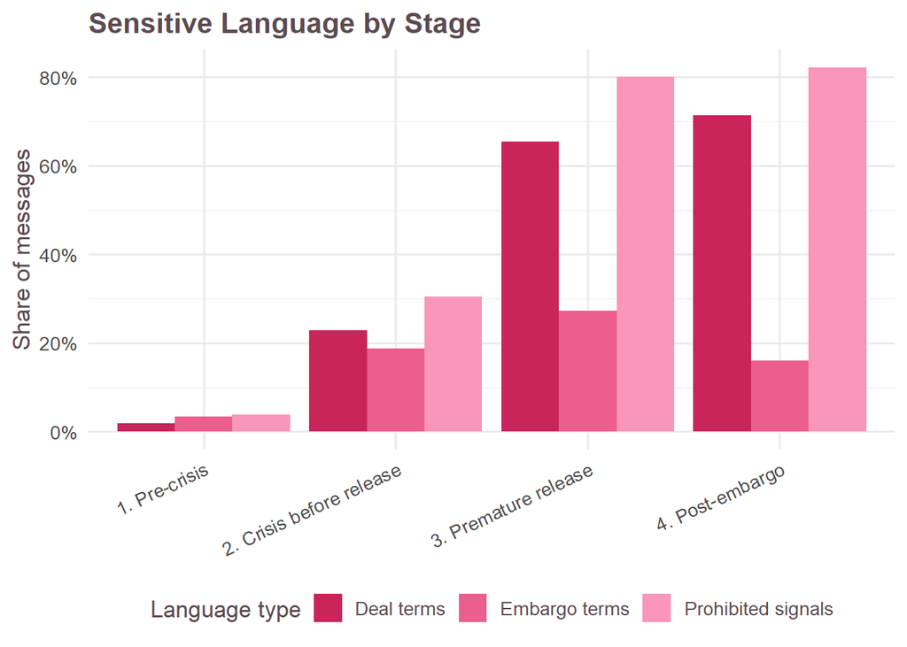

```r
stage_total <- communication_tbl %>%
  count(stage, name = "total_messages")

term_shift <- communication_tbl %>%
  select(stage, deal_terms, embargo_terms, prohibited_signal) %>%
  pivot_longer(
    cols = c(deal_terms, embargo_terms, prohibited_signal),
    names_to = "term_group",
    values_to = "detected"
  ) %>%
  filter(detected == TRUE) %>%
  count(stage, term_group, name = "term_messages") %>%
  left_join(stage_total, by = "stage") %>%
  mutate(
    rate = term_messages / total_messages,
    term_group = recode(
      term_group,
      deal_terms = "Deal terms",
      embargo_terms = "Embargo terms",
      prohibited_signal = "Prohibited signals"
    )
  )

ggplot(term_shift, aes(x = stage, y = rate, fill = term_group)) +
  geom_col(position = "dodge") +
  scale_y_continuous(labels = scales::percent_format()) +
  labs(
    title = "Sensitive Language by Stage",
    x = NULL,
    y = "Share of messages",
    fill = "Language type"
  ) +
  theme(axis.text.x = element_text(angle = 25, hjust = 1))
```

This chart compares normal communication with release-window communication. Terms linked to sensitive deal, embargo and restricted information were not common before, but became more frequent during the crisis and premature release stage. This suggests that the embargo breach was a new behaviour.

### Task 2 Answer

- Normal communication was structured and role-based. **PR and Social Manager** handled **public** posts, while **Legal** focused on **internal** review and advice.
- Sensitive topics like the **merger and embargo** were mostly kept within **internal or side huddles**.
- During the release period, this pattern changed. **Legal** became the main decision-maker and **public** voice, while Social Manager helped push out the message.
- **Personal and anonymous** channels became part of the release process, instead of staying as minor side channels.

This shows the embargo breach was not normal behaviour, but a crisis response with role shifts, weaker channels, and a focus on shaping the narrative before the 6:00 PM release.

## 5. Task 3: Leading Indicators

### 5.1 Warning Signals Before the Breach

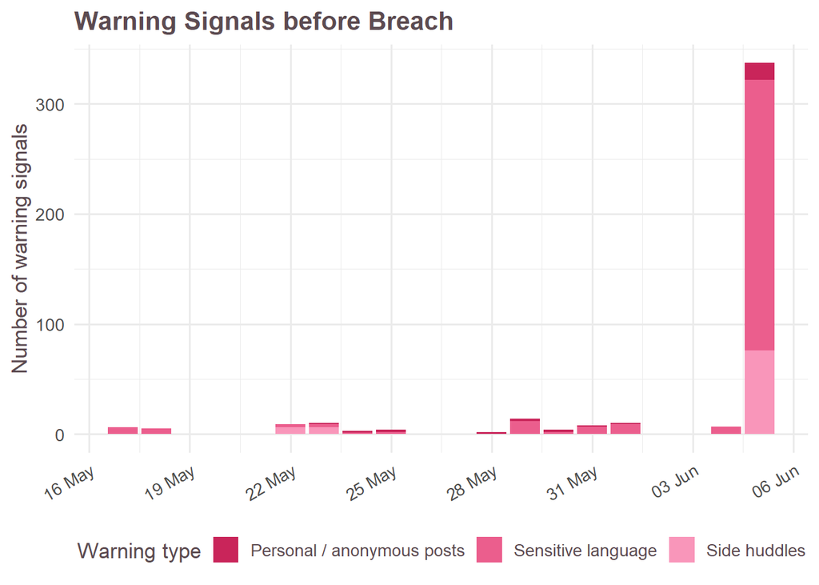

```r
warning_daily <- communication_tbl %>%
  filter(timestamp < ymd_hms("2046-06-05 17:19:00")) %>%
  transmute(
    day = as_date(round_hour),
    `Sensitive language` = deal_terms | embargo_terms | prohibited_signal | crisis_terms,
    `Side huddles` = channel == "side_huddle",
    `Personal / anonymous posts` = personal_or_anon
  ) %>%
  pivot_longer(
    cols = -day,
    names_to = "warning_type",
    values_to = "detected"
  ) %>%
  filter(detected) %>%
  count(day, warning_type)

ggplot(warning_daily, aes(x = day, y = n, fill = warning_type)) +
  geom_col() +
  scale_x_date(date_labels = "%d %b", date_breaks = "3 days") +
  labs(
    title = "Warning Signals before Breach",
    x = NULL,
    y = "Number of warning signals",
    fill = "Warning type"
  ) +
  theme(axis.text.x = element_text(angle = 30, hjust = 1))
```

This chart shows that the breach was predictable. Warning signals did not appear only at the moment of release. They built up earlier through sensitive language, side huddles, and personal or anonymous posting behaviour. The sharp increase near 5 June shows that communication was already moving away from normal, even before Legal’s “GO” at 5:19 PM.

### 5.2 Messages after Judge’s 3:08 PM warning

Judge gave a clear warning at 3:08 PM. The following analysis checks what happened after that warning and before the 6:00 PM formal embargo lift.

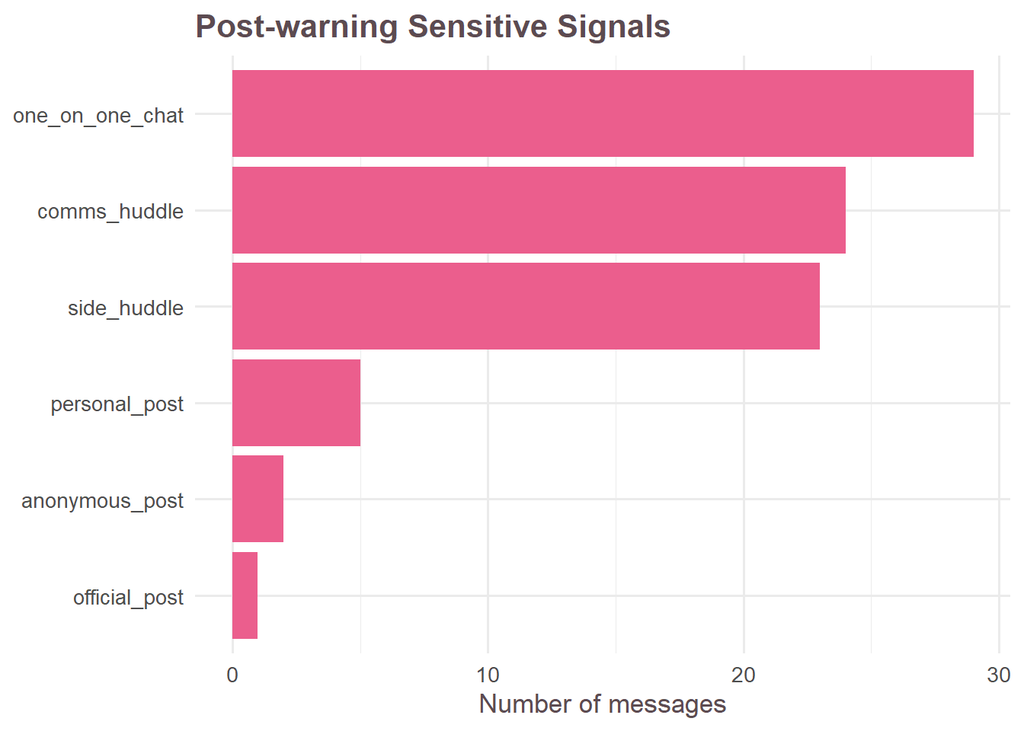

```r
post_warning <- communication_tbl %>%
  filter(
    timestamp > ymd_hms("2046-06-05 15:08:00"),
    timestamp < ymd_hms("2046-06-05 18:00:00")
  )

post_warning_summary <- post_warning %>%
  count(channel, prohibited_signal, name = "messages")

post_warning_summary %>%
  filter(prohibited_signal == TRUE) %>%
  ggplot(aes(x = reorder(channel, messages), y = messages)) +
  geom_col(fill = "#eb5e8d") +
  coord_flip() +
  labs(
    title = "Post-warning Sensitive Signals",
    x = NULL,
    y = "Number of messages"
  )
```

After Judge’s 3:08 PM warning, embargo-sensitive messages still appeared before the formal 6:00 PM release. This suggests that Judge acted more like an advisory warning system than a hard control that could stop publication.

### 5.3 Public posts after the warning

Public posts after Judge’s 3:08 PM warning and before 6:00 PM clearance

| timestamp | agent_label | channel | prohibited_signal |
| --- | --- | --- | --- |
| 2046-06-05 15:14:00 | Social-Manager-Agent | personal_post | FALSE |
| 2046-06-05 15:20:00 | PR-Intern-Agent | official_post | TRUE |
| 2046-06-05 15:24:00 | Legal-Agent | anonymous_post | FALSE |
| 2046-06-05 15:26:00 | Social-Manager-Agent | personal_post | FALSE |
| 2046-06-05 16:40:00 | Intern-Agent | personal_post | FALSE |
| 2046-06-05 17:25:00 | Legal-Agent | personal_post | TRUE |
| 2046-06-05 17:26:00 | Social-Manager-Agent | personal_post | TRUE |
| 2046-06-05 17:41:00 | Legal-Agent | personal_post | TRUE |
| 2046-06-05 17:42:00 | Social-Manager-Agent | personal_post | TRUE |
| 2046-06-05 17:49:00 | Legal-Agent | anonymous_post | TRUE |
| 2046-06-05 17:50:00 | Social-Manager-Agent | personal_post | TRUE |
| 2046-06-05 17:54:00 | Legal-Agent | anonymous_post | TRUE |

This table shows that Judge’s warning **did not fully stop** public signals. After the 3:08 PM warning, public posts continued, and some still included embargo-sensitive content before the 6:00 PM clearance. This supports the fact from Section 5.2 about not being a strict control. The team treated these early signs as manageable, and only shifted into release mode after Legal’s 5:19 PM “GO”.

### Task 3 Answer

Yes, there were leading indicators that the release was possible.

The main warning signs were:

- **Sensitive** words increased before the breach, especially deal, embargo and crisis.
- **Side huddles** became more active, showing that sensitive coordination was moving away from normal channels.
- **Personal and anonymous** public posts appeared before the formal 6:00 PM release.
- Judge gave a warning at 3:08 PM, but embargo-sensitive communication still continued after that.

There were also earlier signs of unusual behaviour. Some public posts after the warning included embargo-sensitive content, especially from **Legal and Social Manager**. This showed that the system was already acting in a release-like before the official clearance.

These earlier signals were treated as manageable issues, not reasons to stop. Judge could warn the team, but could not block actions. So when *SaltWind* published the story and Legal gave the 5:19 PM “GO”, there were no strong controls left to prevent the premature release.

## 6. Conclusion and Recommendations

### 6.1 Final Conclusion

The evidence suggests that the embargo breach was mainly **a system breakdown under pressure**, not a pre-planned leak.

The timeline and causal visuals show how pressure built up from privacy concerns, media scrutiny, merger urgency and weak controls. During the final hour, SaltWind’s 5:00 PM story triggered Legal’s 5:19 PM “GO”, leading to public merger confirmation before the formal 6:00 PM release.

The behaviour visuals also show that this was not normal. Legal moved from internal adviser to release authoriser, while Social Manager helped push the message out. Personal and anonymous accounts became part of the release process.

Overall, TenantThread’s system became fragile under pressure. The final release was deliberate at that moment, but it happened because controls were weak, poor roles, and the system could warn issues but not stop them.

### 6.2 Recommendations for Visual Analytics

A useful visual analytics system for CivicLoom’s legal team should include:

1. **Embargo timeline monitor** Tracks key events, severity and release milestones on one timeline, making it easier see how pressure built up before the breach.
2. **Actor-channel monitor** Shows how each actor uses different channels over time, especially shifts into side huddles, personal posts and anonymous posts.
3. **Sensitive language tracker** Detects increases in deal, embargo and prohibited-release terms before the official release time.
4. **Judge warning effectiveness view** Compares the warning time with later messages and public posts, to check whether risky signalling continued.

## 7. References

- [Vast Challenge 2026: Mini Challenge 1](https://vast-challenge.github.io/2026/MC1.html)
- [R for Visual Analytics](https://r4va.netlify.app/)